# Tugas 4 MPDW

## Pembangkitan Proses AR

```r
set.seed(1041)
```

Nilai-nilai selanjutnya dapat dicari melalui *loop*. Bentuk loop dapat dilihat dari rumus AR(1) yang hendak dibangkitkan:

$$Y_t = e_t+0.7Y_{t-1}$$

```r
set.seed(1041)
n<-length(wn)
n
```

```
## [1] 300
```

```r
ar <- c(1:n)
for (i in 3:n) {ar[i]<-wn[i]+0.5*ar[i-1]+0.2*ar[i-1]}
ar
```

```
##   [1]  1.000000000  2.000000000  0.332814096  1.165924159  0.349081746
##   [6]  1.345170807 -0.323041238  1.295309800  0.205960881  0.116079329
##  [11] -0.926487672  0.664464541  1.922901103  2.099304206 -0.169252359
##  [16]  0.401832239 -0.006035361  0.252385034 -0.226647899  1.700422030
##  [21]  0.860774486 -0.987340701 -1.091848129  0.886274309 -0.361202947
##  [26]  0.262490152 -0.533883120 -0.183537683 -1.177000613  0.191772154
##  [31] -0.183296463  0.062666548 -0.455062388  0.736039910 -1.425188128
##  [36] -2.876866614  1.019518197 -1.039413201 -0.867459256 -0.729686515
##  [41] -0.784762662 -1.228404503 -1.356593890  0.065204509 -0.923608341
##  [46] -0.164014115  2.430415681  1.231508505  0.793847727  1.218068066
##  [51] -1.018499446 -0.589076539 -0.756505819 -0.587896954  0.800667226
##  [56] -0.380473914 -0.295793894  0.801598351 -0.855961981 -1.351326946
##  [61] -0.760296728 -1.149928168 -0.624547979 -0.021243066  1.057512629
##  [66]  1.126349310  0.598052944  1.172534816  1.921880270  3.014524515
##  [71]  2.398986045  1.210120087  2.775139562  2.460487575  2.062529003
```

[output cut: 45 more lines]

Selain menggunakan cara di atas, pembangkitan proses AR dapat dilakukan dengan fungsi `arima.sim()` sebagai berikut.

```r
ar1 <- arima.sim(list(order=c(2,0,0), ar=c(0.5,0.2)), n=300)
ar1
```

```
## Time Series:
## Start = 1
## End = 300
## Frequency = 1
##   [1]  0.427798272 -0.624254391 -0.036387040 -1.191568633  0.412610858
##   [6] -0.349545268  0.098723610 -0.519476220  0.814590193 -1.637016213
##  [11] -2.534824992  1.438509088 -1.540786393 -0.622561395 -0.741903011
##  [16] -0.769445886 -1.212174185 -1.256687008  0.144041891 -1.148567953
##  [21] -0.062963875  2.284030033  0.659639770  0.718417666  1.153511444
##  [26] -1.150707838 -0.220778556 -0.684683088 -0.444840136  0.852838409
##  [31] -0.603489795 -0.160639370  0.807636432 -1.045390484 -1.113321515
##  [36] -0.580106720 -1.130438122 -0.500838666 -0.060566438  0.941931823
##  [41]  0.844943094  0.420466338  1.133119543  1.751758938  2.771711704
##  [46]  2.025026524  1.097685458  2.881903536  2.178378741  2.005757778
##  [51]  2.036560697  1.372637831  1.409201371  1.192342117  0.160941957
```

[output cut: 49 more lines]

## Karakteristik AR(1)

### Plot Time Series

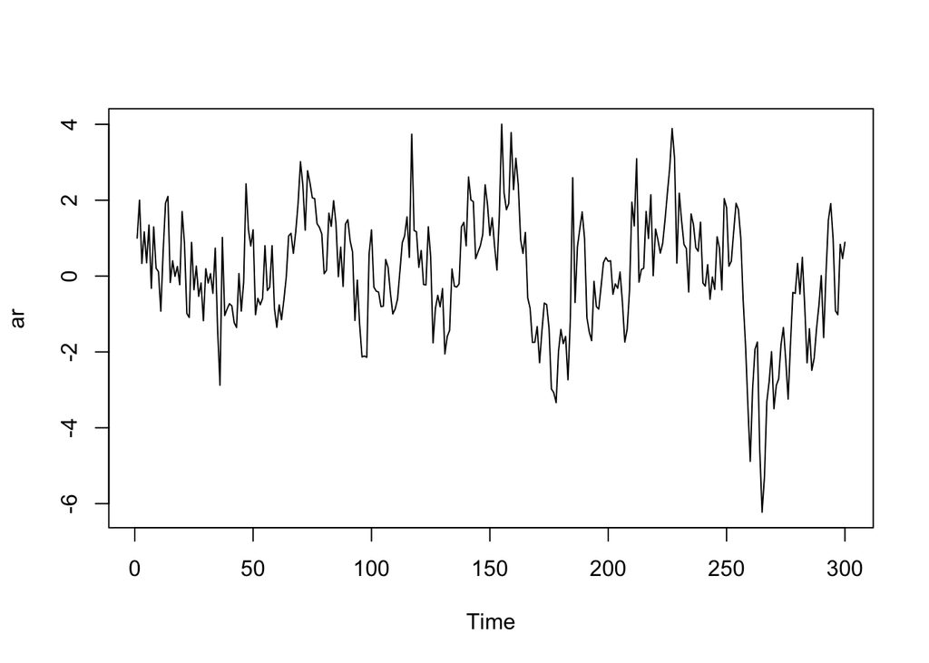

```r
ts.plot(ar)
```

Berdasarkan plot time series tersebut terlihat bahwa data cenderung stasioner pada rataan

### Plot ACF

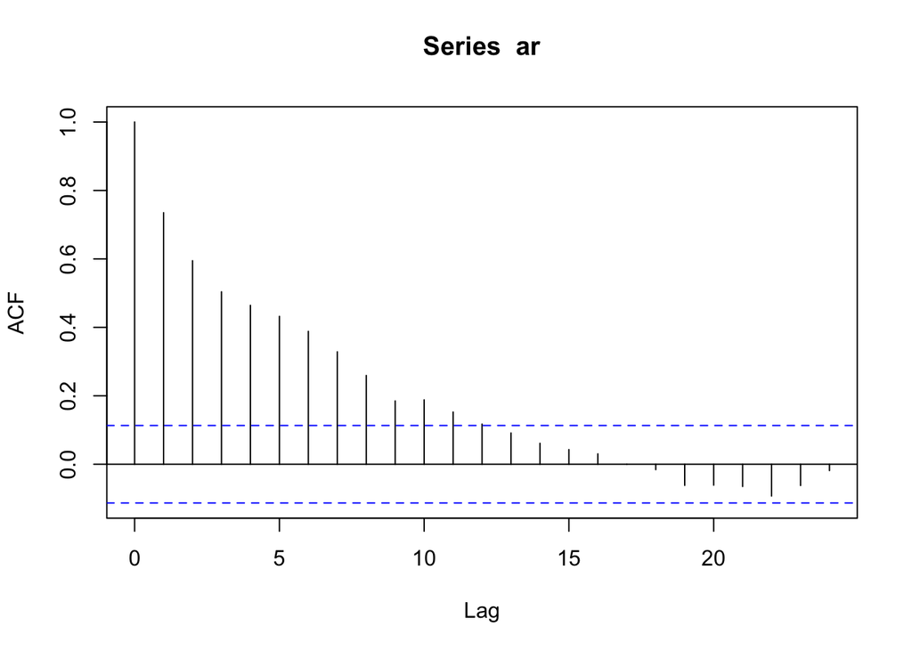

```r
acf(ar)
```

### Plot PACF

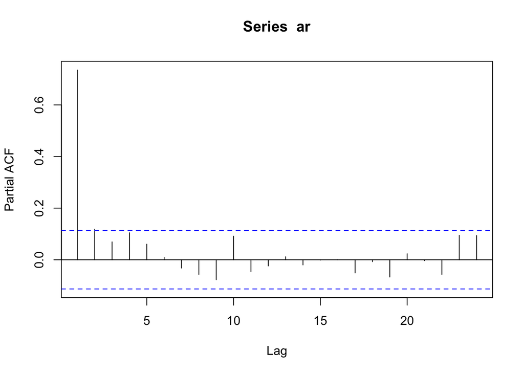

```r
pacf(ar)
```

Berdasarkan plot PACF tersebut, terlihat bahwa plot PACF *cuts off* pada lag pertama, sejalan dengan teori yang ada

### Plot EACF

```r
TSA::eacf(ar)
```

```
## AR/MA
##   0 1 2 3 4 5 6 7 8 9 10 11 12 13
## 0 x x x x x x x x x x x  o  o  o
## 1 x o o o o o o o x o o  o  o  o
## 2 x o o o o o o o o o o  o  o  o
## 3 x x o o o o o o o o o  o  o  o
## 4 x x o o o o o o o o o  o  o  o
## 5 x x o o o o o o o o o  o  o  o
## 6 x x o o o o o o o o o  o  o  o
## 7 x o o o o o o o o o o  o  o  o
```

### Scatterplot Antar Lag

#### Korelasi antara $Y_t$ dengan $Y_{t-1}$

```r
#Yt
yt_ar <- ar[-1]
yt_ar
```

```
##   [1]  2.000000000  0.332814096  1.165924159  0.349081746  1.345170807
##   [6] -0.323041238  1.295309800  0.205960881  0.116079329 -0.926487672
##  [11]  0.664464541  1.922901103  2.099304206 -0.169252359  0.401832239
##  [16] -0.006035361  0.252385034 -0.226647899  1.700422030  0.860774486
##  [21] -0.987340701 -1.091848129  0.886274309 -0.361202947  0.262490152
##  [26] -0.533883120 -0.183537683 -1.177000613  0.191772154 -0.183296463
##  [31]  0.062666548 -0.455062388  0.736039910 -1.425188128 -2.876866614
##  [36]  1.019518197 -1.039413201 -0.867459256 -0.729686515 -0.784762662
##  [41] -1.228404503 -1.356593890  0.065204509 -0.923608341 -0.164014115
##  [46]  2.430415681  1.231508505  0.793847727  1.218068066 -1.018499446
##  [51] -0.589076539 -0.756505819 -0.587896954  0.800667226 -0.380473914
##  [56] -0.295793894  0.801598351 -0.855961981 -1.351326946 -0.760296728
##  [61] -1.149928168 -0.624547979 -0.021243066  1.057512629  1.126349310
##  [66]  0.598052944  1.172534816  1.921880270  3.014524515  2.398986045
##  [71]  1.210120087  2.775139562  2.460487575  2.062529003  2.041776362
```

[output cut: 45 more lines]

```r
#Yt-1
yt_1_ar <- ar[-300]
yt_1_ar
```

```
##   [1]  1.000000000  2.000000000  0.332814096  1.165924159  0.349081746
##   [6]  1.345170807 -0.323041238  1.295309800  0.205960881  0.116079329
##  [11] -0.926487672  0.664464541  1.922901103  2.099304206 -0.169252359
##  [16]  0.401832239 -0.006035361  0.252385034 -0.226647899  1.700422030
##  [21]  0.860774486 -0.987340701 -1.091848129  0.886274309 -0.361202947
##  [26]  0.262490152 -0.533883120 -0.183537683 -1.177000613  0.191772154
##  [31] -0.183296463  0.062666548 -0.455062388  0.736039910 -1.425188128
##  [36] -2.876866614  1.019518197 -1.039413201 -0.867459256 -0.729686515
##  [41] -0.784762662 -1.228404503 -1.356593890  0.065204509 -0.923608341
##  [46] -0.164014115  2.430415681  1.231508505  0.793847727  1.218068066
##  [51] -1.018499446 -0.589076539 -0.756505819 -0.587896954  0.800667226
##  [56] -0.380473914 -0.295793894  0.801598351 -0.855961981 -1.351326946
##  [61] -0.760296728 -1.149928168 -0.624547979 -0.021243066  1.057512629
##  [66]  1.126349310  0.598052944  1.172534816  1.921880270  3.014524515
##  [71]  2.398986045  1.210120087  2.775139562  2.460487575  2.062529003
```

[output cut: 45 more lines]

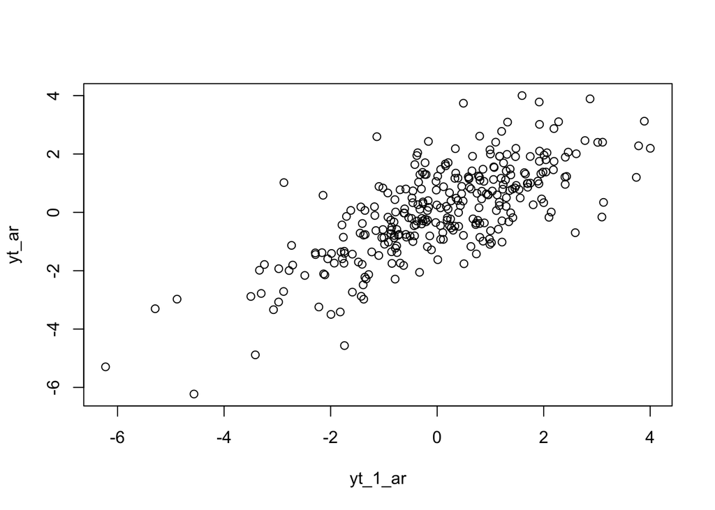

```r
plot(y=yt_ar,x=yt_1_ar)
```

Berdasarkan scatterplot tersebut, terlihat bahwa terdapat hubungan positif antara $Y_t$ dengan $Y_{t-1}$. Hal ini sesuai dengan teori yang ada

```r
cor(yt_ar,yt_1_ar)
```

```
## [1] 0.7357989
```

Korelasi antara $Y_t$ dengan $Y_{t-1}$ dari hasil simulasi mendekati perhitungan teoritis yaitu $\rho_1=\phi^1=0.7$

#### Korelasi antara $Y_t$ dengan $Y_{t-2}$

```r
#Yt
yt_ar2 <- ar[-c(1,2)]
yt_ar2
```

```
##   [1]  0.332814096  1.165924159  0.349081746  1.345170807 -0.323041238
##   [6]  1.295309800  0.205960881  0.116079329 -0.926487672  0.664464541
##  [11]  1.922901103  2.099304206 -0.169252359  0.401832239 -0.006035361
##  [16]  0.252385034 -0.226647899  1.700422030  0.860774486 -0.987340701
##  [21] -1.091848129  0.886274309 -0.361202947  0.262490152 -0.533883120
##  [26] -0.183537683 -1.177000613  0.191772154 -0.183296463  0.062666548
##  [31] -0.455062388  0.736039910 -1.425188128 -2.876866614  1.019518197
##  [36] -1.039413201 -0.867459256 -0.729686515 -0.784762662 -1.228404503
##  [41] -1.356593890  0.065204509 -0.923608341 -0.164014115  2.430415681
##  [46]  1.231508505  0.793847727  1.218068066 -1.018499446 -0.589076539
##  [51] -0.756505819 -0.587896954  0.800667226 -0.380473914 -0.295793894
##  [56]  0.801598351 -0.855961981 -1.351326946 -0.760296728 -1.149928168
##  [61] -0.624547979 -0.021243066  1.057512629  1.126349310  0.598052944
##  [66]  1.172534816  1.921880270  3.014524515  2.398986045  1.210120087
##  [71]  2.775139562  2.460487575  2.062529003  2.041776362  1.382449381
```

[output cut: 45 more lines]

```r
#Yt-2
yt_2_ar <- ar[-c(299,300)]
yt_2_ar
```

```
##   [1]  1.000000000  2.000000000  0.332814096  1.165924159  0.349081746
##   [6]  1.345170807 -0.323041238  1.295309800  0.205960881  0.116079329
##  [11] -0.926487672  0.664464541  1.922901103  2.099304206 -0.169252359
##  [16]  0.401832239 -0.006035361  0.252385034 -0.226647899  1.700422030
##  [21]  0.860774486 -0.987340701 -1.091848129  0.886274309 -0.361202947
##  [26]  0.262490152 -0.533883120 -0.183537683 -1.177000613  0.191772154
##  [31] -0.183296463  0.062666548 -0.455062388  0.736039910 -1.425188128
##  [36] -2.876866614  1.019518197 -1.039413201 -0.867459256 -0.729686515
##  [41] -0.784762662 -1.228404503 -1.356593890  0.065204509 -0.923608341
##  [46] -0.164014115  2.430415681  1.231508505  0.793847727  1.218068066
##  [51] -1.018499446 -0.589076539 -0.756505819 -0.587896954  0.800667226
##  [56] -0.380473914 -0.295793894  0.801598351 -0.855961981 -1.351326946
##  [61] -0.760296728 -1.149928168 -0.624547979 -0.021243066  1.057512629
##  [66]  1.126349310  0.598052944  1.172534816  1.921880270  3.014524515
##  [71]  2.398986045  1.210120087  2.775139562  2.460487575  2.062529003
```

[output cut: 45 more lines]

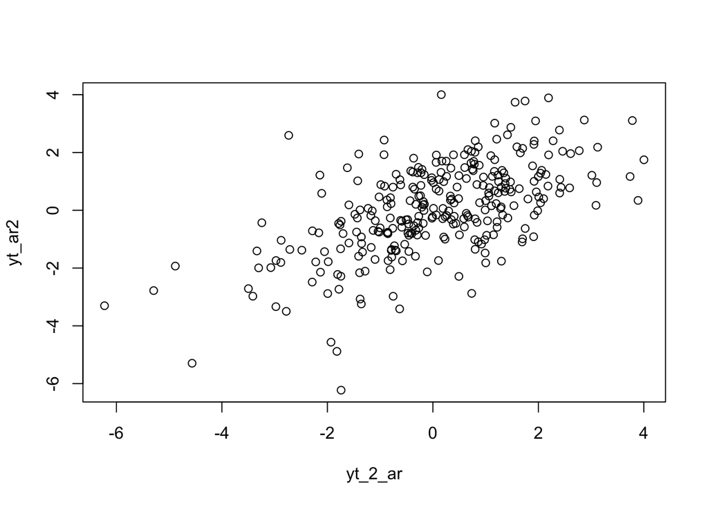

```r
plot(y=yt_ar2,x=yt_2_ar)
```

Berdasarkan scatterplot tersebut, terlihat bahwa terdapat hubungan positif antara $Y_t$ dengan $Y_{t-2}$. Hal ini sesuai dengan teori yang ada

```r
cor(yt_ar2,yt_2_ar)
```

```
## [1] 0.5969387
```

## Fungsi pembangkitan ARMA

Setelah mengetahui cara membangkitkan data berpola AR, MA, dan ARMA sederhana, bagaimana cara melakukan pembangkitan data berpola tersebut yang lebih kompleks? Apakah dapat dibuat suatu fungsi yang fleksibel yang memungkinan pembangkitan dengan berapapun jumlah koefisien?

Pertama, lihat kembali bentuk umum data berpola ARMA.

$$y_{t} = c + \sum_{i=1}^p \phi_{i}y_{t-i} + \sum_{j=1}^q e_{t-j}+ e_{t}$$

Komponen $c$ dan $e_{t}$ cukup mudah untuk dibuat dan dicari. Bagaimana untuk komponen AR dan MA? Bayangkan ada koefisien dan data sebagai berikut:

$$\begin{aligned}
\begin{bmatrix}
\phi_1 \ \phi_2 \ \phi_3
\end{bmatrix}&=
\begin{bmatrix}
0.3 \ 0.5 \ 0.2
\end{bmatrix}
\\
\begin{bmatrix}
y_{t-1} \ y_{t-2} \ y_{t-3}
\end{bmatrix}&=
\begin{bmatrix}
1 \ 2 \ 3
\end{bmatrix}
\end{aligned}$$

Maka dari itu,

$$\begin{aligned}
\begin{bmatrix}
\phi_1 \ \phi_2 \ \phi_3
\end{bmatrix}
\begin{bmatrix}
y_{t-1} \\ y_{t-2} \\ y_{t-3}
\end{bmatrix} &= \phi_1 \ y_{t-1}+\phi_2 \ y_{t-2}+\phi_3 \ y_{t-3}
\\
\begin{bmatrix}
0.3 \ 0.5 \ 0.2
\end{bmatrix}
\begin{bmatrix}
1 \\ 2 \\ 3
\end{bmatrix} & = 0.3 \cdot1+0.5 \cdot 2+0.2 \cdot 3\\
&=0.3+1+0.6 = 1.9
\end{aligned}$$

Jika koefisien dan *white noise*/nilai deret waktu sebelumnya dapat diekstrak dalam bentuk vektor, dapat dilakukan perkalian matriks untuk mencari nilai bagian AR dan MA:

```r
set.seed(1041)
coefs <- c(0.4, 0.6, 0.5, 0.2)
e <- c(1, 2, 3, 4)

coefs %*% e
```

```
##      [,1]
## [1,]  3.9
```

Atau, dapat dilakukan perkalian *elementwise* yang dijumlahkan:

```r
coefs * e
```

```
## [1] 0.4 1.2 1.5 0.8
```

```r
sum(coefs * e)
```

```
## [1] 3.9
```

Dari prinsip ini, dapat dibuat fungsi umum untuk membangkitkan data ARMA. Input dari fungsi adalah jumlah data yang hendak dibangkitkan, koefisien MA, dan koefisien AR

```r
arma.sim <- function(n, macoef, arcoef){
  manum <- length(macoef)
  arnum <- length(arcoef)
  stopifnot(manum < n & arnum < n)

  wn <- rnorm(n, sd = 0.5)
  init <- max(manum, arnum)

  arma <- wn[1:init]
  for(i in {init+1}:n){
   mastart <- i - manum
   maend <- i-1
   arstart <- i - arnum
   arend <- i-1
   arma[i] <- sum(arcoef * arma[arstart:arend]) + sum(macoef * wn[mastart:maend])  + wn[i]
   }
  return(arma)
}
```

Terlihat bahwa komponen $\sum_{i=1}^q y_{t-1}$ disimulasikan melalui `sum(arcoef * arma[arstart:arend])`. Jadi, koefisien dikalikan dengan data $y$ dari $t-q$ di mana q adalah jumlah koefisien AR, sampai data $t-1$. Lalu komponen $\sum_{j=1}^q e_{t-j}$ disimulasikan melalui `sum(macoef * wn[mastart:maend])`. Koefisien dikalikan dengan *white noise* $e$ dari $t-p$, p jumlah koefisien MA, sampai $t-1$.

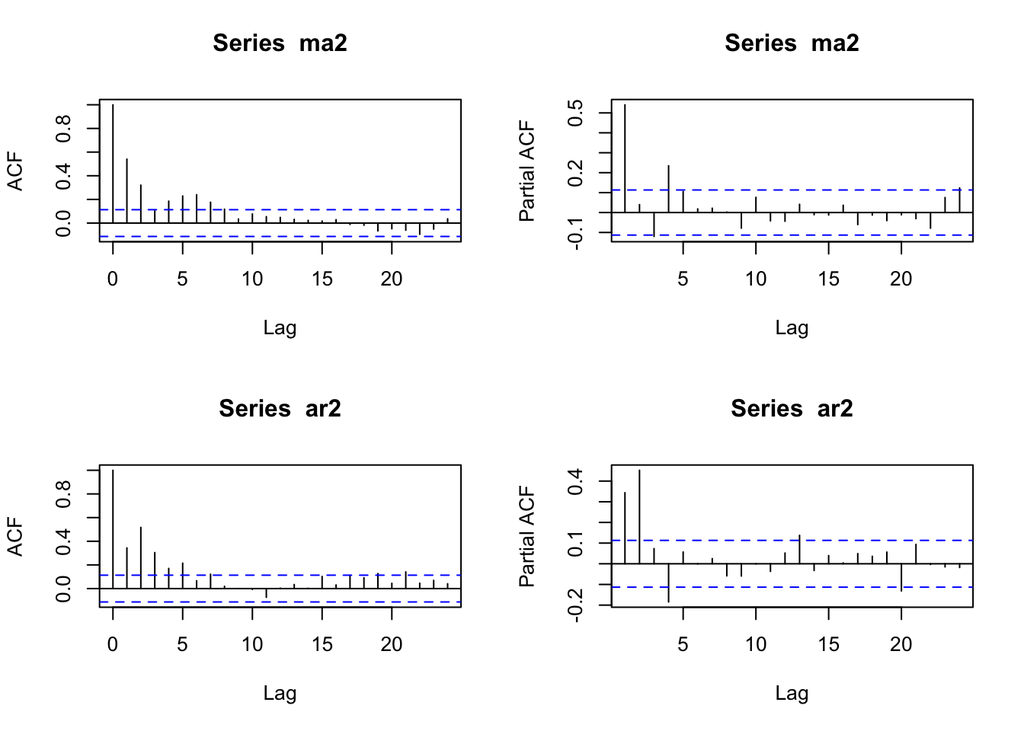

```r
# beberapa contoh pembangkitan melalui fungsi

ma2 <- arma.sim(300, c(0.4, 0.6), 0)
ar2 <- arma.sim(300, 0, c(0.5, 0.2))

par(mfrow = c(2, 2))
acf(ma2)
pacf(ma2)
acf(ar2)
pacf(ar2)
```

```r
set.seed(1041)
n = length(wn)
phi1 = 0.5
theta1 = 0.4
phi2 = 0.2
theta2 = 0.6

y.arma=c(1:n)
for (i in 3:n){y.arma[i] = phi1*y.arma[i-1] + theta1*wn[i-1]+wn[i] + phi2*y.arma[i-2] + theta2*wn[i-2]+wn[i]}
y.arma
```

```
##   [1]   1.000000000   2.000000000  -1.788655413   0.419653366  -1.349164557
##   [6]   1.983922073  -1.647107145   2.770732005  -0.495788400   0.882626435
##  [11]  -2.105021771   1.330072971   3.080140424   4.683545590   0.856245203
##  [16]   2.201907438  -0.077568723   1.112074863  -0.335858002   3.765275994
##  [21]   1.658064297  -0.614041374  -1.610492801   1.258867763  -1.236053189
##  [26]   1.262114202  -1.434230081  -0.062182361  -2.769489202   0.328862699
##  [31]  -1.247385940   0.306416476  -1.208259446   1.481333589  -3.259341175
##  [36]  -5.235289995   0.881192812  -4.026824495  -0.998149196  -2.657163138
##  [41]  -2.209083635  -3.177187586  -3.459849513  -0.941848489  -2.993495492
##  [46]  -0.498902456   3.853754587   2.195129118   3.071121372   2.990183051
##  [51]  -1.408953458  -0.209728014  -2.148098209  -1.296017521   1.116933288
##  [56]  -1.132746495  -0.050970230   1.188924293  -1.864109215  -2.160216751
##  [61]  -2.232775869  -3.160911484  -1.801916341  -0.999731009   1.559134029
##  [66]   2.030319174   1.744069100   2.941391547   4.209045550   6.923998749
##  [71]   6.209793123   4.668408571   7.417897187   6.168130184   6.612009183
```

[output cut: 45 more lines]

Pembangkitan ARMA(p,q) juga dapat dilakukan dengan fungsi `arima.sim` sebagai berikut.

```r
arma22 <- arima.sim(list(order=c(2,0,2), ar = c(0.5,0.2), ma = c(0.4,0.6)), n=300)
arma22
```

```
## Time Series:
## Start = 1
## End = 300
## Frequency = 1
##   [1] -0.02822088 -1.57976969 -0.08515783 -0.89891533  0.20687360 -0.68940779
##   [7]  0.66626726 -1.62268794 -2.70074172 -0.55752723 -2.48619892 -0.37571040
##  [13] -1.91535359 -1.43970900 -1.96506772 -2.20320392 -1.08592195 -1.84495160
##  [19] -0.43595693  1.56971057  1.53547868  2.35269558  1.83666541 -0.25825034
##  [25]  0.01104694 -1.46341787 -0.85117948  0.26409328 -0.52925792  0.10966821
##  [31]  0.38128715 -0.81871927 -1.04689565 -1.65266946 -2.03047360 -1.30107786
##  [37] -0.93916471  0.61720210  1.18537600  1.32360270  1.80827196  2.45728658
##  [43]  4.15228702  4.18476658  3.57072310  4.53599364  3.98975143  4.60625140
##  [49]  4.14589106  3.39071678  3.18019292  2.57960536  1.48339963  1.21023538
##  [55]  2.06597770  2.11293925  3.52883813  2.69492456  1.70752743  1.76908252
##  [61]  0.13785239  2.12673859  1.75596524  2.33408203  1.77475892 -0.33391597
```

[output cut: 39 more lines]

## Karakteristik ARMA(2,2)

### Plot Time Series

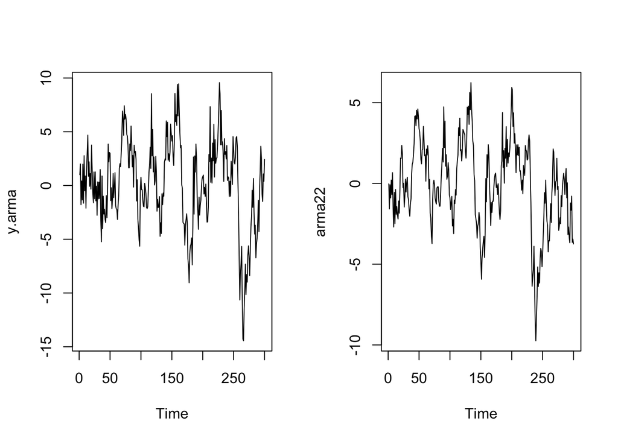

```r
par(mfrow = c(1, 2))
ts.plot(y.arma)
ts.plot(arma22)
```

```r
par(mfrow = c(1, 1))
```

### Plot ACF

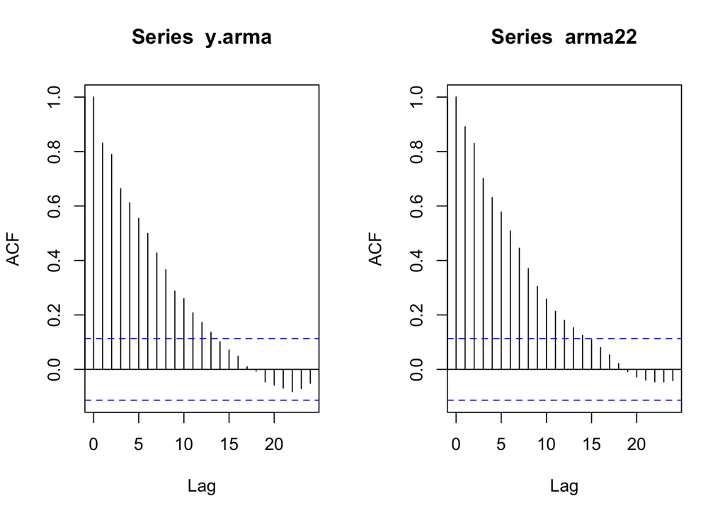

```r
par(mfrow = c(1, 2))
acf(y.arma)
acf(arma22)
```

```r
par(mfrow = c(2, 2))
```

### Plot PACF

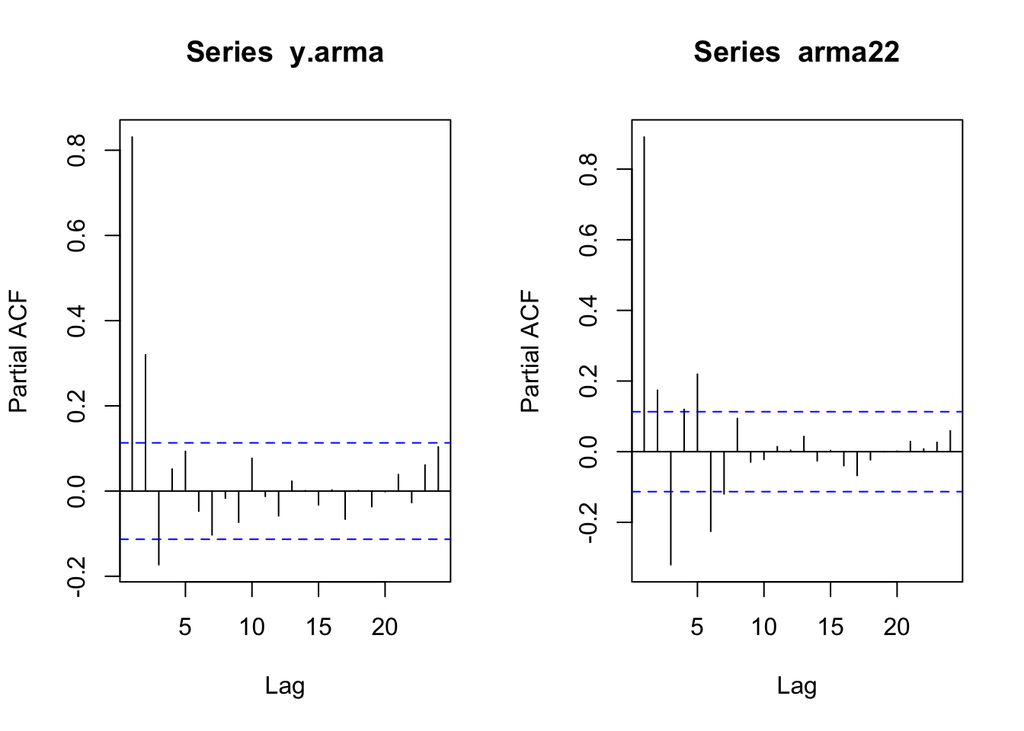

```r
par(mfrow = c(1, 2))
pacf(y.arma)
pacf(arma22)
```

```r
par(mfrow = c(2, 2))
```

### Plot EACF

```r
TSA::eacf(y.arma)
```

```
## AR/MA
##   0 1 2 3 4 5 6 7 8 9 10 11 12 13
## 0 x x x x x x x x x x x  x  x  o
## 1 x x x o o o o o x o o  o  o  o
## 2 x o x o o o o o o o o  o  o  o
## 3 x x x o o o o o o o o  o  o  o
## 4 x x o o x o o o o o o  o  o  o
## 5 x x x o o o o o o o o  o  o  o
## 6 x x x o x o o o o o o  o  o  o
## 7 x x x x x x x o o o o  o  o  o
```

```r
TSA::eacf(arma22)
```

```
## AR/MA
##   0 1 2 3 4 5 6 7 8 9 10 11 12 13
## 0 x x x x x x x x x x x  x  x  x
## 1 x x x o o o o o o o o  o  o  o
## 2 x x x o x o o o o o o  o  o  o
## 3 x x o o x o o o o o o  o  o  o
## 4 x x o o x o o o o o o  o  o  o
## 5 x x o x x x o o o o o  o  o  o
## 6 x x x x x x o o o o o  o  o  o
## 7 x x o o o x o o o o o  o  o  o
```

### Scatterplot Antar Lag

#### Korelasi antara $Y_t$ dengan $Y_{t-1}$

```r
#Yt
yt_arma <- arma22[-1]
yt_arma
```

```
##   [1] -1.57976969 -0.08515783 -0.89891533  0.20687360 -0.68940779  0.66626726
##   [7] -1.62268794 -2.70074172 -0.55752723 -2.48619892 -0.37571040 -1.91535359
##  [13] -1.43970900 -1.96506772 -2.20320392 -1.08592195 -1.84495160 -0.43595693
##  [19]  1.56971057  1.53547868  2.35269558  1.83666541 -0.25825034  0.01104694
##  [25] -1.46341787 -0.85117948  0.26409328 -0.52925792  0.10966821  0.38128715
##  [31] -0.81871927 -1.04689565 -1.65266946 -2.03047360 -1.30107786 -0.93916471
##  [37]  0.61720210  1.18537600  1.32360270  1.80827196  2.45728658  4.15228702
##  [43]  4.18476658  3.57072310  4.53599364  3.98975143  4.60625140  4.14589106
##  [49]  3.39071678  3.18019292  2.57960536  1.48339963  1.21023538  2.06597770
##  [55]  2.11293925  3.52883813  2.69492456  1.70752743  1.76908252  0.13785239
##  [61]  2.12673859  1.75596524  2.33408203  1.77475892 -0.33391597  0.24721732
##  [67] -1.83676489 -2.15775023 -3.28138327 -3.72447980 -1.06992889 -0.03898027
##  [73]  0.19833178 -0.07521589 -0.90626033 -1.15076412 -1.27715186 -0.27460204
##  [79] -0.20892062 -0.21110982 -1.11997295 -1.41066075 -1.40858319 -0.54092595
##  [85]  0.45850221  1.21503868  2.17022355  1.32485994  4.74043303  2.21598015
```

[output cut: 35 more lines]

```r
#Yt-1
yt_1_arma <- arma22[-300]
yt_1_arma
```

```
##   [1] -0.02822088 -1.57976969 -0.08515783 -0.89891533  0.20687360 -0.68940779
##   [7]  0.66626726 -1.62268794 -2.70074172 -0.55752723 -2.48619892 -0.37571040
##  [13] -1.91535359 -1.43970900 -1.96506772 -2.20320392 -1.08592195 -1.84495160
##  [19] -0.43595693  1.56971057  1.53547868  2.35269558  1.83666541 -0.25825034
##  [25]  0.01104694 -1.46341787 -0.85117948  0.26409328 -0.52925792  0.10966821
##  [31]  0.38128715 -0.81871927 -1.04689565 -1.65266946 -2.03047360 -1.30107786
##  [37] -0.93916471  0.61720210  1.18537600  1.32360270  1.80827196  2.45728658
##  [43]  4.15228702  4.18476658  3.57072310  4.53599364  3.98975143  4.60625140
##  [49]  4.14589106  3.39071678  3.18019292  2.57960536  1.48339963  1.21023538
##  [55]  2.06597770  2.11293925  3.52883813  2.69492456  1.70752743  1.76908252
##  [61]  0.13785239  2.12673859  1.75596524  2.33408203  1.77475892 -0.33391597
##  [67]  0.24721732 -1.83676489 -2.15775023 -3.28138327 -3.72447980 -1.06992889
##  [73] -0.03898027  0.19833178 -0.07521589 -0.90626033 -1.15076412 -1.27715186
##  [79] -0.27460204 -0.20892062 -0.21110982 -1.11997295 -1.41066075 -1.40858319
##  [85] -0.54092595  0.45850221  1.21503868  2.17022355  1.32485994  4.74043303
```

[output cut: 35 more lines]

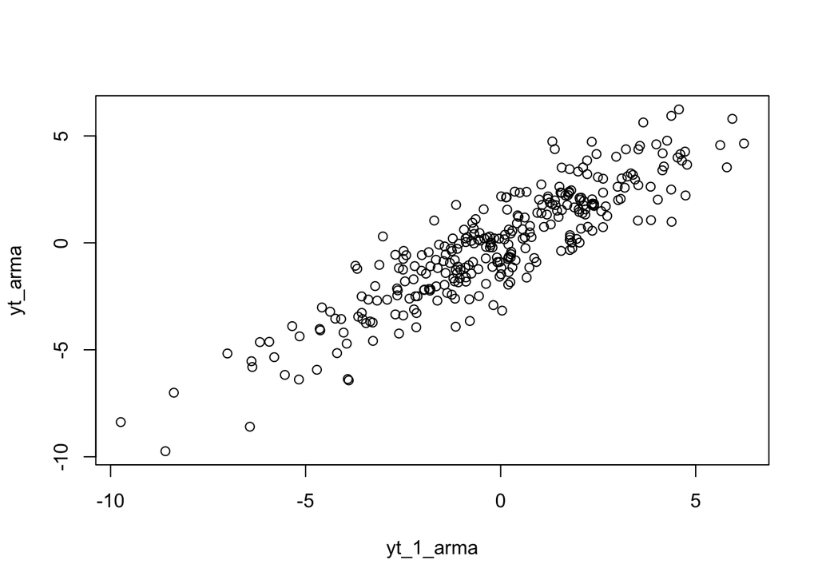

```r
plot(y=yt_arma,x=yt_1_arma)
```

Berdasarkan scatterplot tersebut, terlihat bahwa terdapat hubungan positif antara $Y_t$ dengan $Y_{t-1}$. Hal ini sesuai dengan teori yang ada

```r
cor(yt_arma,yt_1_arma)
```

```
## [1] 0.89366
```

#### Korelasi antara $Y_t$ dengan $Y_{t-2}$

```r
#Yt
yt2_arma <- arma22[-c(1,2)]
yt2_arma
```

```
##   [1] -0.08515783 -0.89891533  0.20687360 -0.68940779  0.66626726 -1.62268794
##   [7] -2.70074172 -0.55752723 -2.48619892 -0.37571040 -1.91535359 -1.43970900
##  [13] -1.96506772 -2.20320392 -1.08592195 -1.84495160 -0.43595693  1.56971057
##  [19]  1.53547868  2.35269558  1.83666541 -0.25825034  0.01104694 -1.46341787
##  [25] -0.85117948  0.26409328 -0.52925792  0.10966821  0.38128715 -0.81871927
##  [31] -1.04689565 -1.65266946 -2.03047360 -1.30107786 -0.93916471  0.61720210
##  [37]  1.18537600  1.32360270  1.80827196  2.45728658  4.15228702  4.18476658
##  [43]  3.57072310  4.53599364  3.98975143  4.60625140  4.14589106  3.39071678
##  [49]  3.18019292  2.57960536  1.48339963  1.21023538  2.06597770  2.11293925
##  [55]  3.52883813  2.69492456  1.70752743  1.76908252  0.13785239  2.12673859
##  [61]  1.75596524  2.33408203  1.77475892 -0.33391597  0.24721732 -1.83676489
##  [67] -2.15775023 -3.28138327 -3.72447980 -1.06992889 -0.03898027  0.19833178
##  [73] -0.07521589 -0.90626033 -1.15076412 -1.27715186 -0.27460204 -0.20892062
##  [79] -0.21110982 -1.11997295 -1.41066075 -1.40858319 -0.54092595  0.45850221
##  [85]  1.21503868  2.17022355  1.32485994  4.74043303  2.21598015  3.85377736
```

[output cut: 35 more lines]

```r
#Yt-1
yt_2_arma <- arma22[-c(299,300)]
yt_2_arma
```

```
##   [1] -0.02822088 -1.57976969 -0.08515783 -0.89891533  0.20687360 -0.68940779
##   [7]  0.66626726 -1.62268794 -2.70074172 -0.55752723 -2.48619892 -0.37571040
##  [13] -1.91535359 -1.43970900 -1.96506772 -2.20320392 -1.08592195 -1.84495160
##  [19] -0.43595693  1.56971057  1.53547868  2.35269558  1.83666541 -0.25825034
##  [25]  0.01104694 -1.46341787 -0.85117948  0.26409328 -0.52925792  0.10966821
##  [31]  0.38128715 -0.81871927 -1.04689565 -1.65266946 -2.03047360 -1.30107786
##  [37] -0.93916471  0.61720210  1.18537600  1.32360270  1.80827196  2.45728658
##  [43]  4.15228702  4.18476658  3.57072310  4.53599364  3.98975143  4.60625140
##  [49]  4.14589106  3.39071678  3.18019292  2.57960536  1.48339963  1.21023538
##  [55]  2.06597770  2.11293925  3.52883813  2.69492456  1.70752743  1.76908252
##  [61]  0.13785239  2.12673859  1.75596524  2.33408203  1.77475892 -0.33391597
##  [67]  0.24721732 -1.83676489 -2.15775023 -3.28138327 -3.72447980 -1.06992889
##  [73] -0.03898027  0.19833178 -0.07521589 -0.90626033 -1.15076412 -1.27715186
##  [79] -0.27460204 -0.20892062 -0.21110982 -1.11997295 -1.41066075 -1.40858319
##  [85] -0.54092595  0.45850221  1.21503868  2.17022355  1.32485994  4.74043303
```

[output cut: 35 more lines]

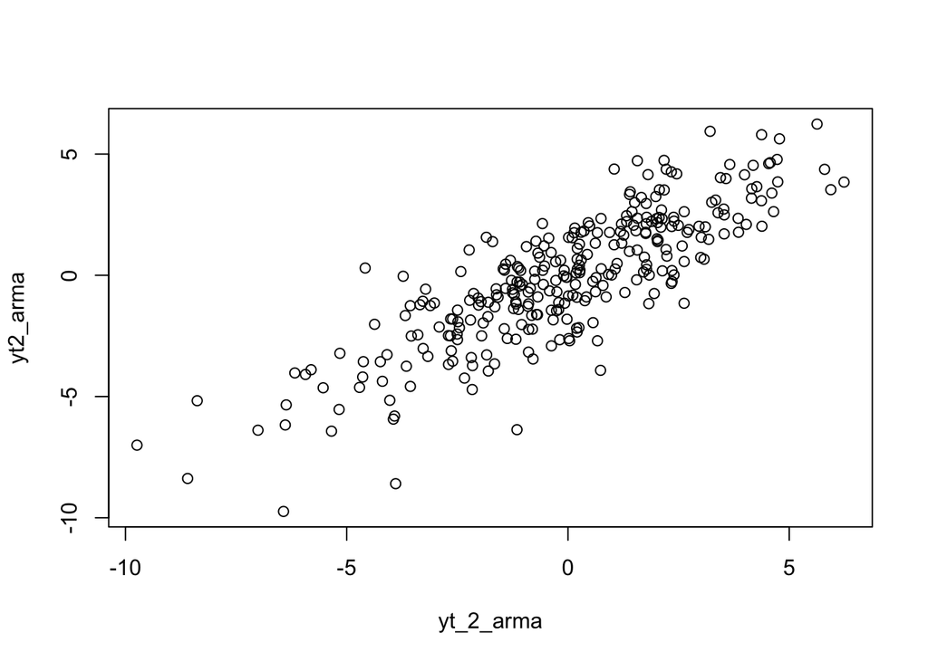

```r
plot(y=yt2_arma,x=yt_2_arma)
```

Berdasarkan scatterplot tersebut, terlihat bahwa terdapat hubungan positif antara $Y_t$ dengan $Y_{t-2}$. Hal ini sesuai dengan teori yang ada

```r
cor(yt2_arma,yt_2_arma)
```

```
## [1] 0.8347571
```

#### Korelasi antara $Y_t$ dengan $Y_{t-3}$

```r
#Yt
yt3_arma <- arma22[-c(1,2,3)]
yt3_arma
```

```
##   [1] -0.89891533  0.20687360 -0.68940779  0.66626726 -1.62268794 -2.70074172
##   [7] -0.55752723 -2.48619892 -0.37571040 -1.91535359 -1.43970900 -1.96506772
##  [13] -2.20320392 -1.08592195 -1.84495160 -0.43595693  1.56971057  1.53547868
##  [19]  2.35269558  1.83666541 -0.25825034  0.01104694 -1.46341787 -0.85117948
##  [25]  0.26409328 -0.52925792  0.10966821  0.38128715 -0.81871927 -1.04689565
##  [31] -1.65266946 -2.03047360 -1.30107786 -0.93916471  0.61720210  1.18537600
##  [37]  1.32360270  1.80827196  2.45728658  4.15228702  4.18476658  3.57072310
##  [43]  4.53599364  3.98975143  4.60625140  4.14589106  3.39071678  3.18019292
##  [49]  2.57960536  1.48339963  1.21023538  2.06597770  2.11293925  3.52883813
##  [55]  2.69492456  1.70752743  1.76908252  0.13785239  2.12673859  1.75596524
##  [61]  2.33408203  1.77475892 -0.33391597  0.24721732 -1.83676489 -2.15775023
##  [67] -3.28138327 -3.72447980 -1.06992889 -0.03898027  0.19833178 -0.07521589
##  [73] -0.90626033 -1.15076412 -1.27715186 -0.27460204 -0.20892062 -0.21110982
##  [79] -1.11997295 -1.41066075 -1.40858319 -0.54092595  0.45850221  1.21503868
##  [85]  2.17022355  1.32485994  4.74043303  2.21598015  3.85377736  1.06452406
```

[output cut: 35 more lines]

```r
#Yt-1
yt_3_arma <- arma22[-c(298,299,300)]
yt_3_arma
```

```
##   [1] -0.02822088 -1.57976969 -0.08515783 -0.89891533  0.20687360 -0.68940779
##   [7]  0.66626726 -1.62268794 -2.70074172 -0.55752723 -2.48619892 -0.37571040
##  [13] -1.91535359 -1.43970900 -1.96506772 -2.20320392 -1.08592195 -1.84495160
##  [19] -0.43595693  1.56971057  1.53547868  2.35269558  1.83666541 -0.25825034
##  [25]  0.01104694 -1.46341787 -0.85117948  0.26409328 -0.52925792  0.10966821
##  [31]  0.38128715 -0.81871927 -1.04689565 -1.65266946 -2.03047360 -1.30107786
##  [37] -0.93916471  0.61720210  1.18537600  1.32360270  1.80827196  2.45728658
##  [43]  4.15228702  4.18476658  3.57072310  4.53599364  3.98975143  4.60625140
##  [49]  4.14589106  3.39071678  3.18019292  2.57960536  1.48339963  1.21023538
##  [55]  2.06597770  2.11293925  3.52883813  2.69492456  1.70752743  1.76908252
##  [61]  0.13785239  2.12673859  1.75596524  2.33408203  1.77475892 -0.33391597
##  [67]  0.24721732 -1.83676489 -2.15775023 -3.28138327 -3.72447980 -1.06992889
##  [73] -0.03898027  0.19833178 -0.07521589 -0.90626033 -1.15076412 -1.27715186
##  [79] -0.27460204 -0.20892062 -0.21110982 -1.11997295 -1.41066075 -1.40858319
##  [85] -0.54092595  0.45850221  1.21503868  2.17022355  1.32485994  4.74043303
```

[output cut: 35 more lines]

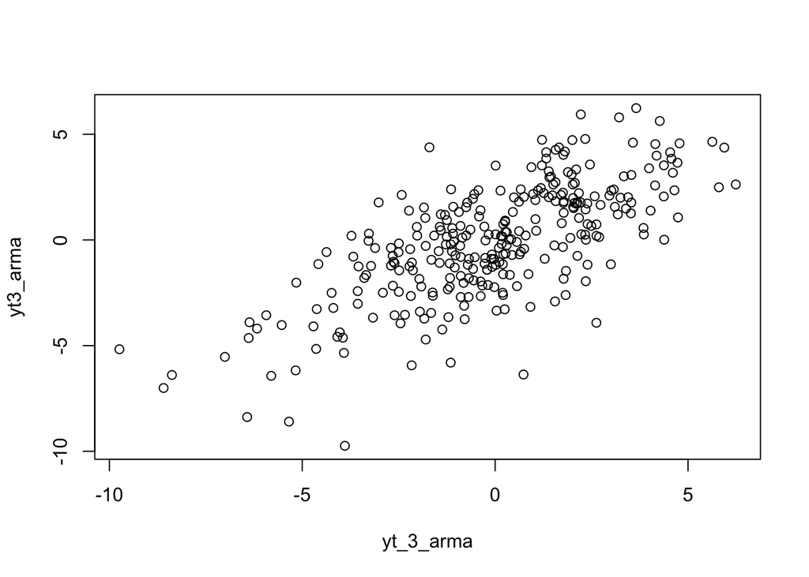

```r
plot(y=yt3_arma,x=yt_3_arma)
```

Berdasarkan scatterplot tersebut, terlihat bahwa terdapat hubungan positif antara $Y_t$ dengan $Y_{t-3}$. Hal ini sesuai dengan teori yang ada

```r
cor(yt3_arma,yt_3_arma)
```

```
## [1] 0.7079405
```

Korelasi antara $Y_t$ dengan $Y_{t-3}$ dari hasil simulasi sebesar 0.7079405